# Where should I live in San Francisco?

Visualizing San Francisco’s Housing Market using Zillow Data

Collin Ching

```r
library(knitr)

opts_chunk$set(echo=FALSE,warning=FALSE,message=FALSE)
```

Moving to San Francisco would be awesome except for the cost of rent.

In this project, I explore neighborhoods through [Zillow data](https://www.zillow.com/research/data/) to find rental opportunities in San Francisco. The following analysis was scripted in R, and analysis is neighborhood-based.

Credit goes to Ken Steif and Keith Hassel for their [great tutorial](http://urbanspatialanalysis.com/dataviz-tutorial-mapping-san-francisco-home-prices-using-r/) for exploring home prices in San Francisco. I used their ggplot themes for my graphics.

# Neighborhood reference

Because my analysis in this post is with respect to neighborhoods, it is helpful to have a visual reference of San Francisco’s neighborhoods and districts.

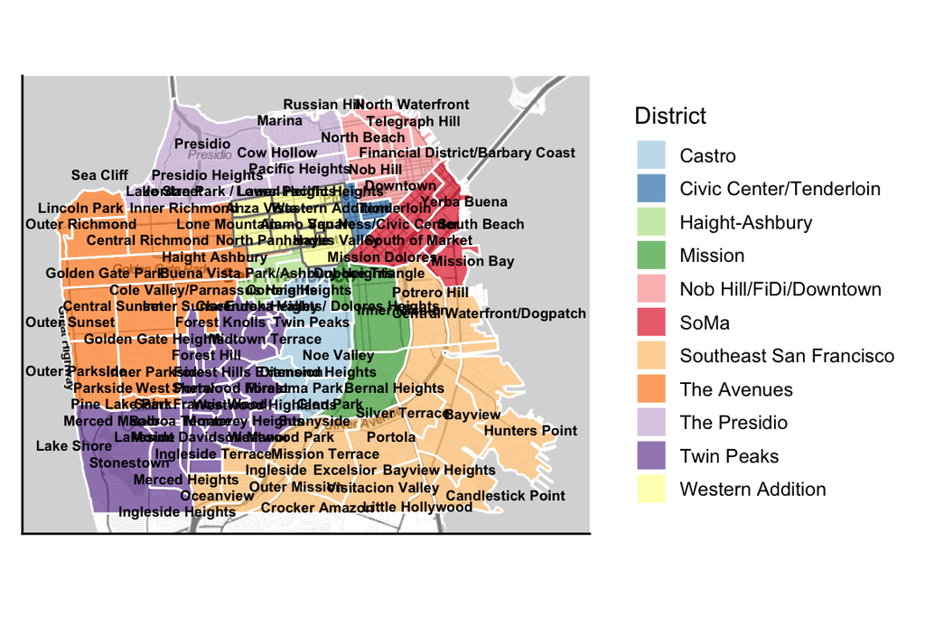

# Change over time

We examine geographic home prices and their change over time. The next few plots were heavily inspired by a tutorial by Ken Steif and Keith Hassel.

# Mapping median San Francisco home prices by year

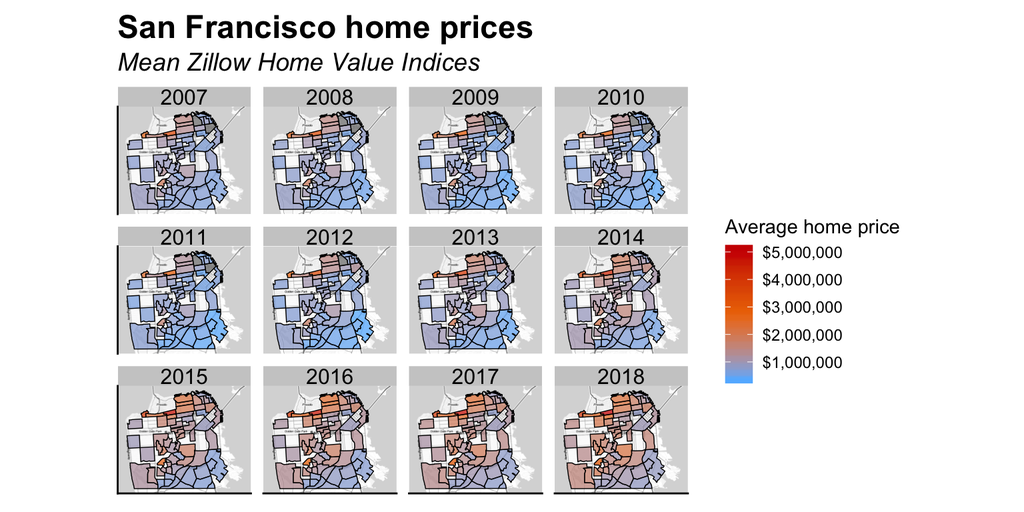

First, neighborhood home prices are stagnant between 2007 and 2011 due to the subprime mortgage crisis. In Southeast the Shipyard, housing prices even decrease during this time period.

# Violin plot: capture changes over time

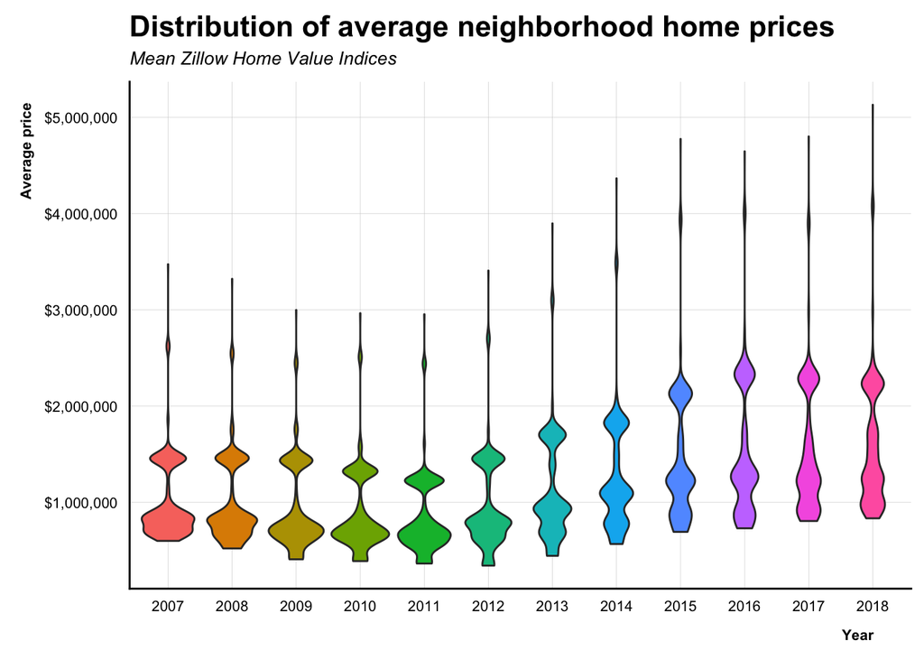

This violin diagram shows the spread and density of yearly neighborhood averages. The vertical line extends out to the most expensive neighborhood’s average home price. From this graphic, we see that housing prices not only remained constant from 2007 to 2011, but actually decrease towards the end of thsi period. As suspected, housing prices do shoot up after 2012. And as they shoot up, the spread in neighborhood prices becomes wider. Housing prices diverge and we see the interesting emergence of a trimodal distribution.

It will be informative to explore how home prices and rent have changed over time, which we’ll do later.

# Univariate housing distributions, 2010-2018

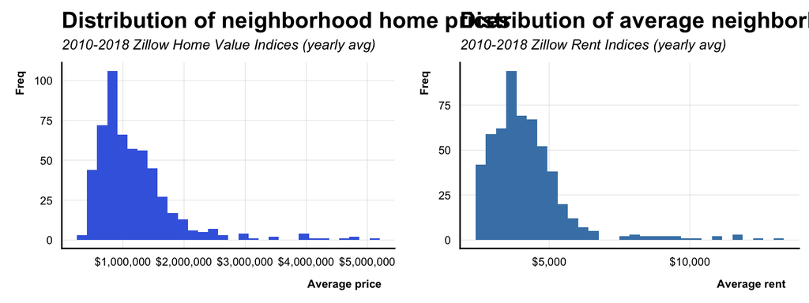

The plots above includes all home types - condos, single-family, multi-family - and home sizes - 1-bedroom, 2-bedroom, 3-bedroom, etc.

The typical home price was a little under $1 million and typical rent was roughly $4,000 per month from 2010 to 2018.

There are also rare neighborhoods where the median home price exceeds $3,000,000 and median rent exceeds $6,000. Home price and rent follow a similar distribution.

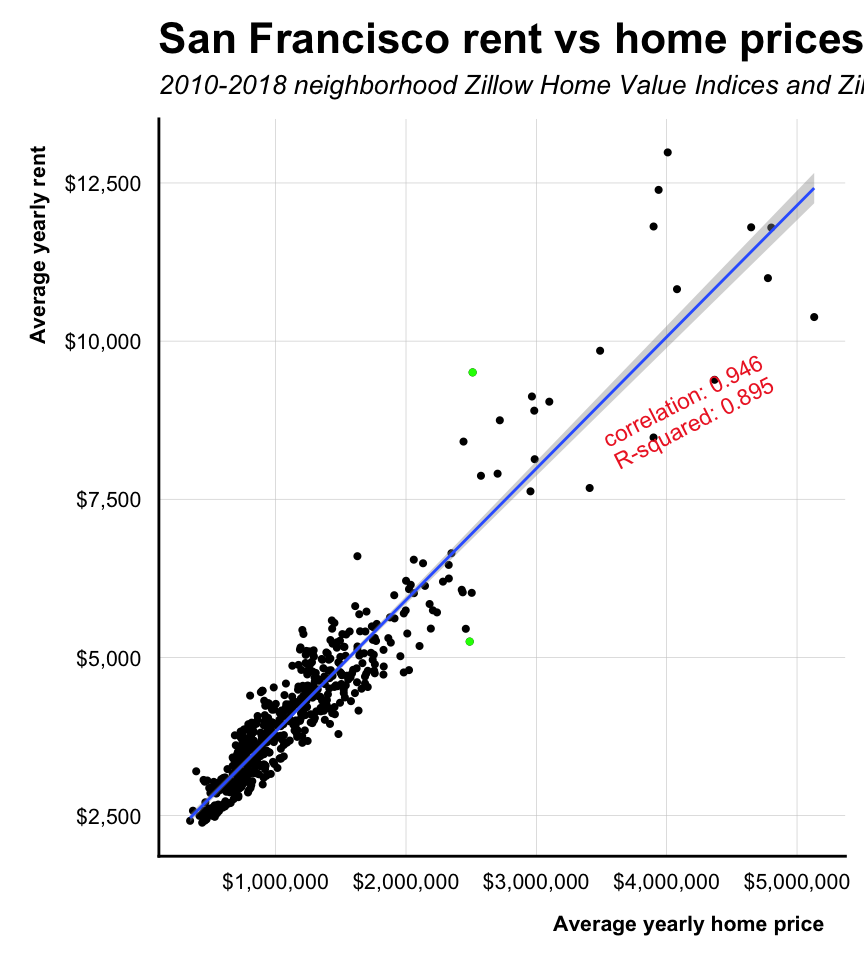

Average yearly home price explains 89.5% of the variation in average yearly rent. Still, rent can vary at a fixed home price: at $2.5m, the minimum rent is $5250/mo and maximum is $9506/mo.

If someone offered me two $2.5m homes to rent – one at $5250/mo and one at $9506/mo – I’d take the $5250/mo most cases.

In the scenario above, I fixed home price. Say you fix your rent budget instead. What is the highest home value you could get for that budget? If you’re purchasing rental properties, what’s the highest monthly rent you could get for a fixed purchasing budget? These questions launch us into the next analysis.

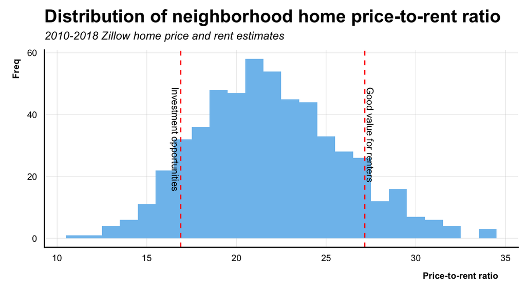

These are average neighborhood price-to-rent ratios from 2010 to 2018, where price-to-rent ratio is
$$\frac{\text{home price}}{12\times \text{monthly rent}}$$
.

Price-to-rent is home price divided by a years estimated rent. You can view it as the estimated years to pay off a rental property. Maximizing this ratio would give renters good value; minimizing this ratio (fewer years to payoff) would give landlords good returns.

If you’re renting an apartment, you want to maximize price-to-rent. These neighborhoods have higher bang for rental buck. Highest 10% neighborhoods are marked in the right panel.

If you’re investing in rental property, you want to minimize price-to-rent so you get quick returns on investment. Lowest 10% price-to-rent neighborhoods are marked in the left.

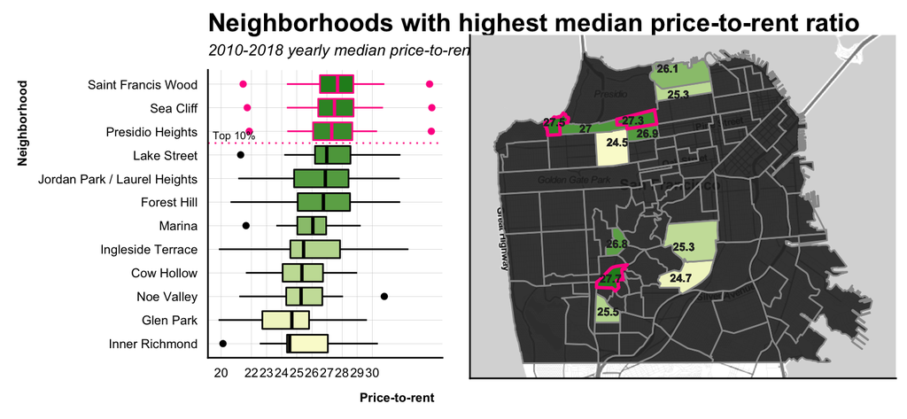

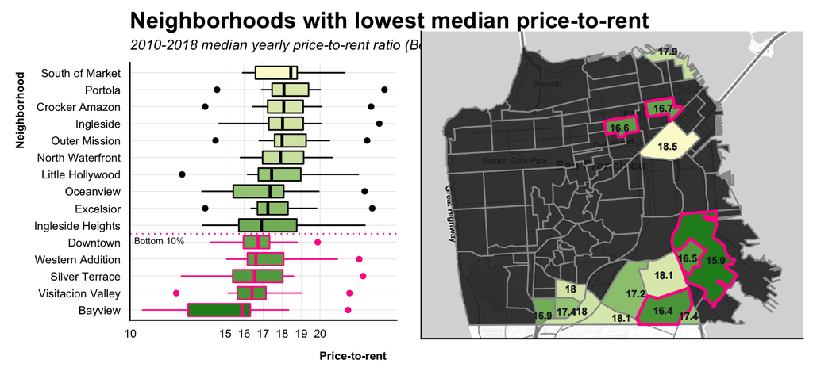

Bayview is a neighborhood with historically high crime rates. It is an area that is quickly gentrifying, though. With coffee shops and eateries sprouting up that are catering to young professionals, it may be suitable for young professionals who need cheap housing in the city.

Next, we will look at change over time. Look at absolute change as well as rate of change. **Is it accelerating or decelerating?** Try to go by like the lowest value?

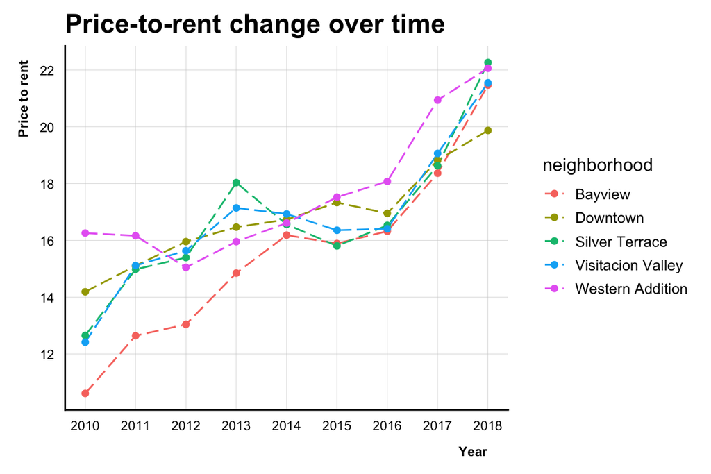

Map places that are most and least expensive, by percentile.

```
##  [1] "Cow Hollow"                   "Forest Hill"
##  [3] "Ingleside Terrace"            "Inner Richmond"
##  [5] "Jordan Park / Laurel Heights" "Lake Street"
##  [7] "Lone Mountain"                "Marina"
##  [9] "Noe Valley"                   "Pacific Heights"
## [11] "Presidio Heights"             "Saint Francis Wood"
## [13] "Sea Cliff"
```

```
##  [1] "Bayview"           "Crocker Amazon"    "Diamond Heights"
##  [4] "Downtown"          "Excelsior"         "Ingleside"
##  [7] "Ingleside Heights" "Little Hollywood"  "Mission Terrace"
## [10] "North Waterfront"  "Oceanview"         "Outer Mission"
## [13] "Portola"           "Silver Terrace"    "South of Market"
## [16] "Visitacion Valley"
```

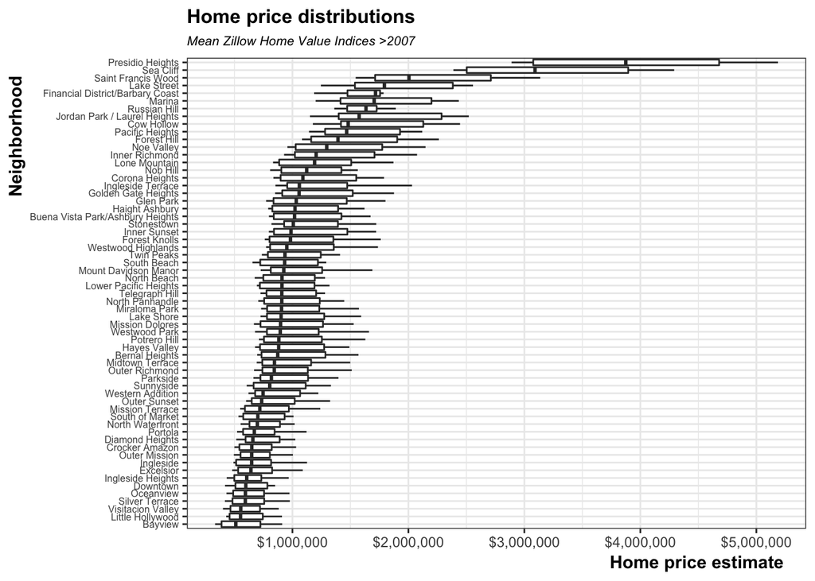

# Conclusion

Studied Urban Spatial for several days. Took time to rerun code, and take notes on everything they did. For me, the keys to understanding how to make the plots was to focus my attention to how ggplot’s geom_polygon() function draws shapes. This helped me to understand why the authors of the article reshaped data the way they did.